# Assessing the Gap

Frequent Mental Distress Trends and Predictive Model Performance Among American Indian/Alaska Native Adults, BRFSS 2014–2024

AIM-AHEAD Research Project

# 1 Executive summary

National health surveys provide important evidence about mental distress, but national prediction accuracy can mask differences in performance for smaller population groups. This study evaluates whether three classifiers trained on pooled national BRFSS data perform comparably for **AI/AN-alone adults** and **other identified single-race adults**, and whether performance differs before and after 2020.

The analysis uses a previously assembled BRFSS 2014–2024 analytical file with 4,790,742 records and 25 selected variables. The main outcome is frequent mental distress (FMD): reporting 14 or more mentally unhealthy days in the previous 30 days. Associations and performance differences are descriptive; this study does not establish causal mechanisms or clinical harms.

# 2 1. Research questions

**Primary research question:** How well do models trained on pooled U.S. BRFSS data classify frequent mental distress among AI/AN-alone adults compared with other identified single-race adults, and does performance differ between 2014–2019 and 2020–2024?

**Supporting questions:** How did the prevalence of FMD differ between periods across the two populations? How did physical-health, demographic, and socioeconomic characteristics relate to FMD, and did selected associations vary by group or period?

# 3 2. Background

BRFSS is an annual, repeated cross-sectional health survey of U.S. adults. FMD captures frequent self-reported poor mental health, not a clinical diagnosis. CDC analyses of earlier BRFSS surveys documented mental-distress differences across racial and ethnic populations and lower distress among respondents with greater socioeconomic resources (CDC, 2004). An analysis of the 2018 BRFSS showed substantial FMD differences by disability status (Cree et al., 2020). These findings motivate studying physical health and socioeconomic characteristics, not assuming they cause distress.

Health surveillance research has emphasized that aggregate AI/AN samples may be small and cannot reflect every Tribal community (Adakai et al., 2018). Healthcare algorithm research has also illustrated how overall model behavior can mask group-level problems when proxies or evaluation targets are poorly aligned with health needs (Obermeyer et al., 2019). That healthcare algorithm studied a different outcome and population; it motivates careful subgroup evaluation rather than establishing an AI/AN bias in the BRFSS models.

**Population definition:** The analysis classifies respondents reporting AI/AN alone separately from respondents classified in other identified single-race categories. Multiracial and unknown-race categories are excluded from this primary two-group comparison. The comparison group should not be interpreted as necessarily free of Indigenous ancestry. The available calculated race-alone indicator cannot identify all AI/AN respondents who also report another race.

# 4 3. Data, outcome and methods

The original pooled dataset was previously created from 11 annual BRFSS files. The reproducible RStudio pipeline starts from that archived file; it does not re-extract the XPT sources.

The binary outcome uses MENTHLTH responses: 14–30 days = 1; 0–13 days = 0. BRFSS code 88 (“none”) is zero days, while codes 77 and 99 (“don’t know”/refused) are missing.

Predictors are physically unhealthy days, general health, income, education, age, recorded sex and the study period. They are measured contemporaneously, so classification here is not prospective clinical prediction.

The project uses a common train/test split stratified by year, group and outcome, with three shared cross-validation folds, followed by a held-out evaluation in both periods. Model training and evaluation use sampling-adjusted weights to account for computational caps on the much larger comparison group.

The primary prevalence estimates use the historical notebook’s pooled weight formula. Alternative pooling approaches are reported as sensitivity checks. This is not an endorsement of a unique official CDC multi-year weighting formula. The reported model metrics are weighted descriptive estimates; no complex-survey confidence intervals are automatically claimed.

# 5 4. Descriptive exploration

## 5.1 4.1 Retention and availability

Group-by-period sample retention.

| study_period | cohort | n | outcome_valid | complete_predictors |
| --- | --- | --- | --- | --- |
| Pre-2020 |  | 117,752 | 114,052 | 79,988 |
| Pre-2020 | Other identified single-race | 2,483,438 | 2,442,707 | 1,994,693 |
| Pre-2020 | AI/AN alone | 51,797 | 50,505 | 40,965 |
| Post-2020 | Other identified single-race | 1,982,928 | 1,947,527 | 1,530,070 |
| Post-2020 |  | 110,922 | 106,821 | 68,222 |
| Post-2020 | AI/AN alone | 43,905 | 42,782 | 33,547 |

**How to read:** Compare `n`, `outcome_valid`, and `complete_predictors` within each group; complete-case exclusion may not affect every population equally.

## 5.2 4.2 FMD prevalence

FMD prevalence (%) by population and period under three weighting choices.

| study_period | cohort | respondents | cases | prevalence_pct | raw_weight_pct | equal_year_mean_pct | largest_sensitivity_difference_pp |
| --- | --- | --- | --- | --- | --- | --- | --- |
| Post-2020 | AI/AN alone | 42,782 | 8,065 | 21.36 | 21.34 | 21.27 | 0.09 |
| Post-2020 | Other identified single-race | 1,947,527 | 254,426 | 14.82 | 14.79 | 14.80 | 0.03 |
| Pre-2020 | AI/AN alone | 50,505 | 8,433 | 17.19 | 17.22 | 17.21 | 0.02 |
| Pre-2020 | Other identified single-race | 2,442,707 | 260,158 | 11.98 | 12.01 | 12.01 | 0.03 |

**How to read:** Each percentage describes respondents reporting 14+ mentally unhealthy days. Values are estimates from repeated cross-sectional surveys, not within-person changes.

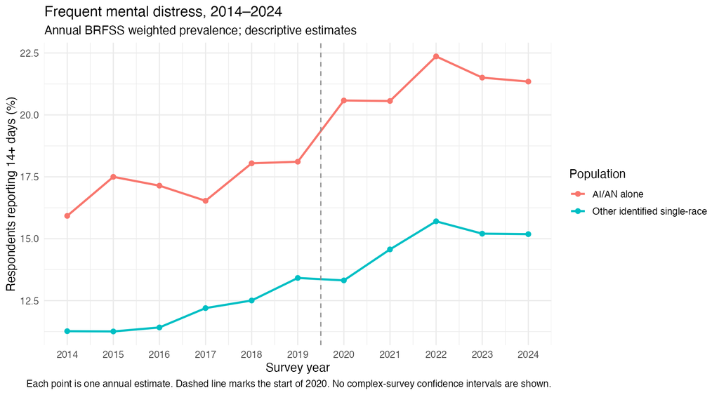

**How to read the graph:** Each point represents one year. The dashed vertical line indicates the start of 2020. Higher values indicate a larger estimated share of respondents reporting FMD. The lines do not establish causes for changes.

# 6 5. Unsupervised learning: PCA

PCA was fit using dummy-coded predictors in a training subsample, excluding FMD as an input. The first two components summarize axes of variation in the recorded predictor combinations.

Variance captured by leading principal components.

| component | explained_variance_pct |
| --- | --- |
| PC1 | 16.38 |
| PC2 | 11.62 |
| PC3 | 10.92 |
| PC4 | 10.59 |
| PC5 | 9.52 |

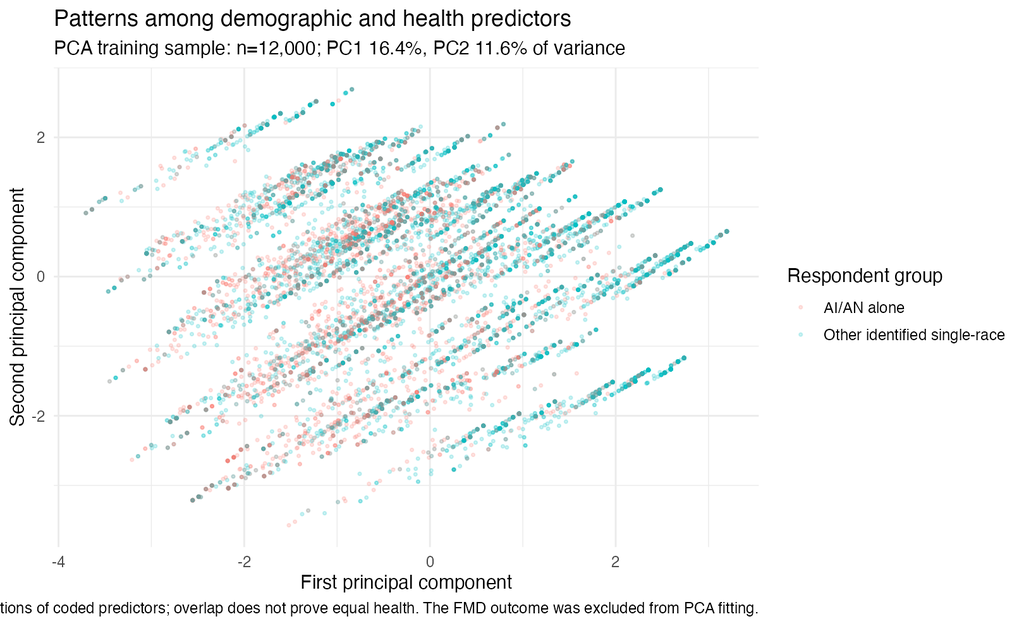

**How to read the graph:** Each point is one respondent. Points close together have similar encoded predictor values. Overlap is expected and does not itself mean that health outcomes are the same. The displayed PCA sample is a computational subsample, not a nationally representative map.

Predictor encodings with the largest absolute PC1 loadings.

| variable | PC1 | PC2 |
| --- | --- | --- |
| EDU_CLEANCollege.grad | 0.480 | 0.029 |
| INCOME_BAND75k. | 0.475 | -0.165 |
| GENHLTH_CLEAN | -0.423 | -0.190 |
| PHYSHLTH_DAYS | -0.348 | -0.271 |
| INCOME_BAND25.49k | -0.285 | 0.254 |
| EDU_CLEANHS | -0.278 | 0.252 |
| EDU_CLEANSome.college | -0.172 | -0.259 |
| AGE_BAND35.49 | 0.169 | 0.165 |

Large absolute loadings indicate which encoded predictors most strongly contribute to the first PCA dimension; the sign of a component is arbitrary.

# 7 6. Supervised learning

## 7.1 6.1 Three-model comparison and cross-validation

The models were: ordinary logistic regression, LASSO-penalized logistic regression and random forest. All three were evaluated using the same cross-validation folds. Hyperparameters were chosen by mean CV AUROC.

Cross-validation winners (higher AUROC is better).

| family | config | cv_mean_auroc | cv_mean_brier |
| --- | --- | --- | --- |
| forest | 2 | 0.7650 | 0.0978 |
| lasso | 0.0003162278 | 0.7652 | 0.0967 |
| logistic | default | 0.7652 | 0.0967 |

```
## The highest mean cross-validated AUROC in this run was achieved by **logistic** (0.765).
```

Cross-validation scores select models; independent held-out scores are the primary evidence for performance across population and period.

## 7.2 6.2 Held-out performance by group and period

Held-out model metrics by group and period.

| family | study_period | cohort | n | events | auroc | average_precision | brier | sensitivity | specificity | calibration_gap |
| --- | --- | --- | --- | --- | --- | --- | --- | --- | --- | --- |
| logistic | Pre-2020 | AI/AN alone | 8,195 | 1,380 | 0.752 | 0.458 | 0.129 | 0.512 | 0.819 | -0.024 |
| logistic | Pre-2020 | Other identified single-race | 359,787 | 38,497 | 0.769 | 0.359 | 0.091 | 0.450 | 0.895 | -0.004 |
| logistic | Post-2020 | AI/AN alone | 6,710 | 1,278 | 0.698 | 0.441 | 0.154 | 0.563 | 0.741 | -0.027 |
| logistic | Post-2020 | Other identified single-race | 296,840 | 39,260 | 0.766 | 0.396 | 0.110 | 0.519 | 0.846 | -0.005 |
| lasso | Pre-2020 | AI/AN alone | 8,195 | 1,380 | 0.752 | 0.458 | 0.129 | 0.513 | 0.819 | -0.025 |
| lasso | Pre-2020 | Other identified single-race | 359,787 | 38,497 | 0.769 | 0.359 | 0.091 | 0.450 | 0.895 | -0.003 |
| lasso | Post-2020 | AI/AN alone | 6,710 | 1,278 | 0.697 | 0.440 | 0.154 | 0.564 | 0.741 | -0.028 |
| lasso | Post-2020 | Other identified single-race | 296,840 | 39,260 | 0.766 | 0.396 | 0.110 | 0.517 | 0.846 | -0.006 |
| forest | Pre-2020 | AI/AN alone | 8,195 | 1,380 | 0.751 | 0.455 | 0.131 | 0.544 | 0.817 | -0.027 |
| forest | Pre-2020 | Other identified single-race | 359,787 | 38,497 | 0.765 | 0.358 | 0.092 | 0.448 | 0.897 | 0.002 |
| forest | Post-2020 | AI/AN alone | 6,710 | 1,278 | 0.695 | 0.455 | 0.156 | 0.511 | 0.779 | -0.048 |
| forest | Post-2020 | Other identified single-race | 296,840 | 39,260 | 0.758 | 0.389 | 0.112 | 0.466 | 0.872 | -0.013 |

**Metric guide:** AUROC and average precision summarize ranking quality (higher is generally better). Brier score measures probability accuracy (lower is better). Sensitivity is the fraction of actual FMD cases classified positive; specificity is the fraction of noncases classified negative. The reported classification threshold is 0.20.

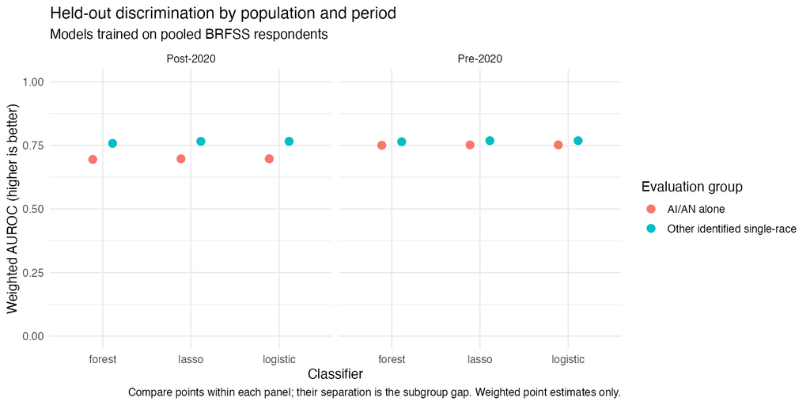

**How to read:** Compare the group points within each period. The distance between the points is a descriptive difference in discrimination. It does not by itself establish algorithmic discrimination or the source of the difference.

## 7.3 6.3 Does the group gap change across periods?

Change in AI/AN-minus-comparison AUROC gap (post minus pre).

| family | auc_gap.Post-2020 | auc_gap.Pre-2020 | change_in_auc_gap |
| --- | --- | --- | --- |
| forest | -0.0630 | -0.0141 | -0.0489 |
| lasso | -0.0686 | -0.0168 | -0.0519 |
| logistic | -0.0686 | -0.0165 | -0.0521 |

A negative result means the AUROC difference became more unfavorable to AI/AN-alone respondents in the later period. These are **observed differences**, not automatically statistically significant changes.

All three fitted classifiers showed a more negative AI/AN-minus-comparison AUROC gap in the later period in this run.

## 7.4 6.4 Calibration

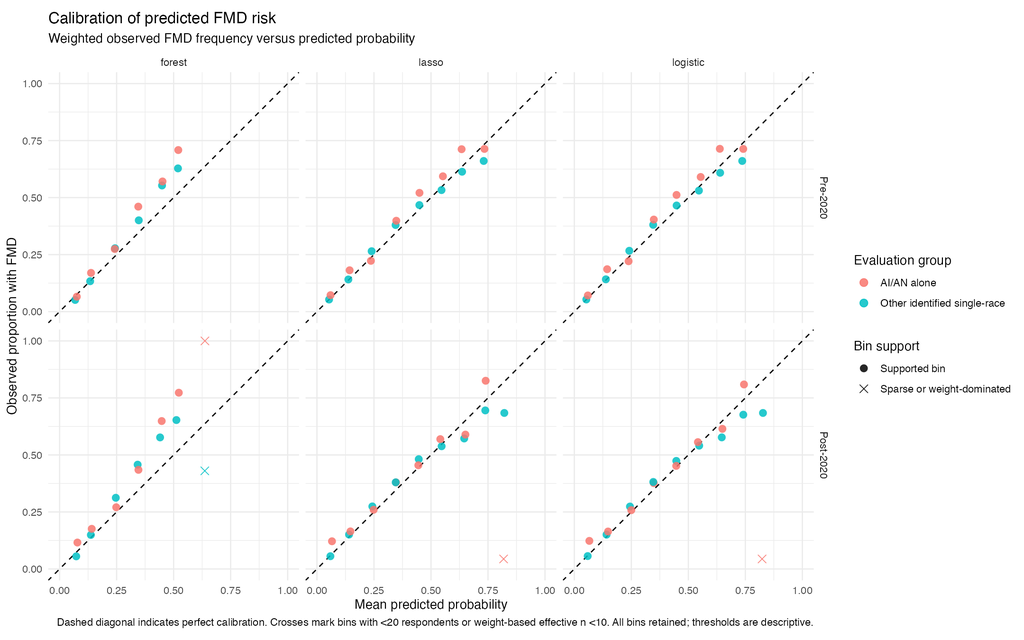

**How to read:** The dashed diagonal is ideal agreement between predicted and observed FMD. Points above the line mean the model predicted a lower probability than the actual observed rate for that bin; points below the line mean predicted risk was too high.

# 8 7. Associated factors and limitations

Exploratory covariate-standardized FMD predictions (%).

| cohort | study_period | adjusted_prediction_pct |
| --- | --- | --- |
| Other identified single-race | Pre-2020 | 11.21 |
| Other identified single-race | Post-2020 | 14.98 |
| AI/AN alone | Pre-2020 | 11.81 |
| AI/AN alone | Post-2020 | 17.39 |

The regression-based associations are exploratory and contemporaneous.

Largest-magnitude signals within each model family.

| family | term | value | type |
| --- | --- | --- | --- |
| forest | PHYSHLTH_DAYS | 1,796.617 | impurity importance (biased by variable scale) |
| forest | GENHLTH_CLEAN | 1,136.895 | impurity importance (biased by variable scale) |
| forest | AGE_BAND65. | 342.660 | impurity importance (biased by variable scale) |
| forest | INCOME_BAND75k. | 183.658 | impurity importance (biased by variable scale) |
| forest | EDU_CLEANCollege.grad | 152.567 | impurity importance (biased by variable scale) |
| forest | SEX_CLEANMale | 125.854 | impurity importance (biased by variable scale) |
| lasso | (Intercept) | -2.735 | penalized log-odds coefficient |
| lasso | AGE_BAND65. | -1.545 | penalized log-odds coefficient |
| lasso | AGE_BAND50.64 | -0.707 | penalized log-odds coefficient |
| lasso | INCOME_BAND75k. | -0.471 | penalized log-odds coefficient |
| lasso | GENHLTH_CLEAN | 0.436 | penalized log-odds coefficient |
| lasso | SEX_CLEANMale | -0.412 | penalized log-odds coefficient |
| logistic | (Intercept) | -2.741 | log-odds coefficient |
| logistic | AGE_BAND65+ | -1.574 | log-odds coefficient |
| logistic | AGE_BAND50-64 | -0.727 | log-odds coefficient |
| logistic | INCOME_BAND75k+ | -0.492 | log-odds coefficient |
| logistic | GENHLTH_CLEAN | 0.439 | log-odds coefficient |
| logistic | SEX_CLEANMale | -0.418 | log-odds coefficient |

Positive logistic coefficients indicate higher fitted log odds relative to their reference values, conditional on the other model terms. LASSO coefficients are penalized; forest impurity importance has an entirely different scale and may favor variables with more possible splits. Coefficient magnitudes therefore should **not** be compared directly across model families.

Key limitations include the use of AI/AN-alone race categories rather than all AI/AN combinations, changes in survey coverage and measurement over time, nominal income brackets across years, incomplete source-level certainty about all year-specific harmonizations, and lack of design-based uncertainty intervals for model-performance gaps. The historical source-file audit identified four differences between an independently calculated 2024 FMD category and the saved outcome; that issue should be resolved or disclosed before any claim of perfect source-category agreement.

# 9 8. Conclusions

The core evaluation tests whether models trained on pooled national data show comparable held-out discrimination and probability accuracy for AI/AN-alone respondents and the other identified single-race comparison population in two time periods. Findings should be summarized directly from the generated performance and gap tables, with the limitations above. Model-performance differences alone do not establish their causes or demonstrate real-world clinical harm.

# 10 References

- CDC. *Frequent Mental Distress Among Adults with Disabilities, 2018.* https://www.cdc.gov/mmwr/volumes/69/wr/mm6936a2.htm
- CDC. *Frequent Mental Distress among Adults, United States, 1993–2001.* https://www.cdc.gov/mmwr/preview/mmwrhtml/mm5341a1.htm
- Adakai M, et al. (2018). *Health Disparities Among American Indians/Alaska Natives, Arizona.* https://www.cdc.gov/mmwr/volumes/67/wr/mm6747a4.htm
- Obermeyer Z, et al. (2019). *Dissecting racial bias in an algorithm used to manage the health of populations.* https://www.science.org/doi/10.1126/science.aax2342
- CDC. BRFSS annual survey documentation and calculated variables. https://www.cdc.gov/brfss/annual_data/annual_data.htm